# Homework 4 | CFRM 505 | Revtsov

```python
import numpy as np
import matplotlib.pyplot as plt
from scipy.special import ndtr
```

# Problem 1

Consider the multivariate normal random variable $\mathbf{X}$ with $\mathbb{E}[X_1] = 1$, $\mathbb{E}[X_2] = -2$, $\mathbb{E}[X_3] = 0$, $\textrm{Var}[X_1] = 2$, $\textrm{Var}[X_2] = 1$, $\textrm{Var}[X_3] = 4$, $\textrm{Corr}[X_1, X_2] = 0.6$, $\textrm{Corr}[X_1, X_3] = -0.3$ and $\textrm{Corr}[X_2, X_3] = 0.5$.

## Part a

Simulate at least $10,000$ samples of $\mathbf{X}$. Calculate the sample means, sample variances and sample correlations of your simulations to confirm that they match the correct values.

## Part b

Make three scatter plots of your simulations, one for each pair of variables. (E.g., plot $X_1$ vs $X_2$, then plot $X_1$ vs $X_3$, then plot $X_2$ vs $X_3$.)

**Solution**

Build the covariance matrix from variances and correlations:

$$\Sigma_{ij} = \mathrm{Corr}[X_i, X_j] \cdot \sqrt{\mathrm{Var}[X_i]} \cdot \sqrt{\mathrm{Var}[X_j]}$$

Then use the Cholesky decomposition $\Sigma = LL^T$ (where $L$ is lower triangular). If $\mathbf{Z} \sim N(\mathbf{0}, I)$ (iid standard normals), then:

$$\mathbf{X} = \boldsymbol{\mu} + L\mathbf{Z} \sim N(\boldsymbol{\mu}, \Sigma)$$

since $\mathrm{Cov}[L\mathbf{Z}] = L\,\mathrm{Cov}[\mathbf{Z}]\,L^T = L I L^T = \Sigma$.

```python
np.random.seed(42)
n = 10_000

mu = np.array([1.0, -2.0, 0.0])
std = np.array([np.sqrt(2), 1.0, 2.0])

corr_mat = np.array([[1.0,  0.6, -0.3],
                     [0.6,  1.0,  0.5],
                     [-0.3, 0.5,  1.0]])

# Build covariance matrix: Cov[i,j] = Corr[i,j] * std[i] * std[j]
Sigma = corr_mat * np.outer(std, std)
print("Covariance matrix:\n", Sigma)

# Cholesky decomposition: Sigma = L @ L.T
L = np.linalg.cholesky(Sigma)
print("\nCholesky factor L:\n", L.round(4))

# Simulate: X = mu + L @ Z, Z ~ iid N(0,1)
Z = np.random.normal(0, 1, (n, 3))
X = mu + Z @ L.T

print("\nSample means:     ", X.mean(axis=0).round(4), " (exact: [1, -2, 0])")
print("Sample variances: ", X.var(axis=0).round(4),  " (exact: [2, 1, 4])")
print("Sample correlations:\n", np.corrcoef(X.T).round(4))
print("Exact correlations:\n", corr_mat)
```

```
Covariance matrix:
 [[ 2.          0.84852814 -0.84852814]
 [ 0.84852814  1.          1.        ]
 [-0.84852814  1.          4.        ]]

Cholesky factor L:
 [[ 1.4142  0.      0.    ]
 [ 0.6     0.8     0.    ]
 [-0.6     1.7     0.866 ]]

Sample means:      [ 0.9919 -2.0013  0.0097]  (exact: [1, -2, 0])
Sample variances:  [2.0149 0.9927 4.033 ]  (exact: [2, 1, 4])
Sample correlations:
 [[ 1.      0.5969 -0.3158]
 [ 0.5969  1.      0.4909]
 [-0.3158  0.4909  1.    ]]
Exact correlations:
 [[ 1.   0.6 -0.3]
 [ 0.6  1.   0.5]
 [-0.3  0.5  1. ]]
```

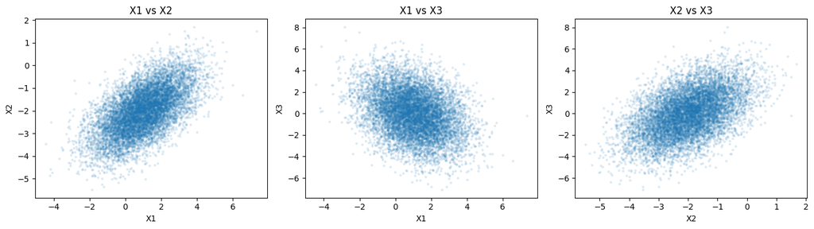

```python
fig, axes = plt.subplots(1, 3, figsize=(14, 4))
pairs = [(0, 1, "X1", "X2"), (0, 2, "X1", "X3"), (1, 2, "X2", "X3")]
for ax, (i, j, li, lj) in zip(axes, pairs):
    ax.scatter(X[:, i], X[:, j], alpha=0.1, s=5)
    ax.set_xlabel(li)
    ax.set_ylabel(lj)
    ax.set_title(f"{li} vs {lj}")
plt.tight_layout()
plt.show()
```

# Problem 2

Consider the multivariate normal random variable $X\sim N(\mathbf{0}, \Sigma)$, where

$$\Sigma = \begin{pmatrix} 1 & -1 \\ -1 & 1 \end{pmatrix}$$

## Part a

What is the Cholesky decomposition of $\Sigma$? Explain why it might be problematic to generate samples of $X$ using this decomposition.

## Part b

What is the pdf of $X$?

## Part c

Generate $1,000$ samples of $X$ and make a scatter plot of the points. How does this plot relate to your answer from parts (a) and (b)?

**Solution**

**Part a : Cholesky decomposition**

For $\Sigma = \begin{pmatrix}1 & -1 \\ -1 & 1\end{pmatrix}$, solve $LL^T = \Sigma$ for lower-triangular $L$:

$$L_{11} = \sqrt{\Sigma_{11}} = 1, \quad L_{21} = \Sigma_{21}/L_{11} = -1, \quad L_{22} = \sqrt{\Sigma_{22} - L_{21}^2} = \sqrt{1-1} = 0$$

$$L = \begin{pmatrix}1 & 0 \\ -1 & 0\end{pmatrix}$$

The zero diagonal entry is problematic: $\Sigma$ is singular (positive semi-definite, not positive definite). Generating $\mathbf{X} = L\mathbf{Z}$ gives $X_1 = Z_1$ and $X_2 = -Z_1$, so all samples are forced onto the line $x_2 = -x_1$.

**Part b : PDF of $X$**

Since $\Sigma$ is singular, the distribution of $X$ is degenerate: there is no 2D pdf because all probability mass lies on the single line $x_2 = -x_1$. Along that line, $X_1 \sim N(0,1)$, so the distribution is fully described by a 1D standard normal.

**Part c : Scatter plot**

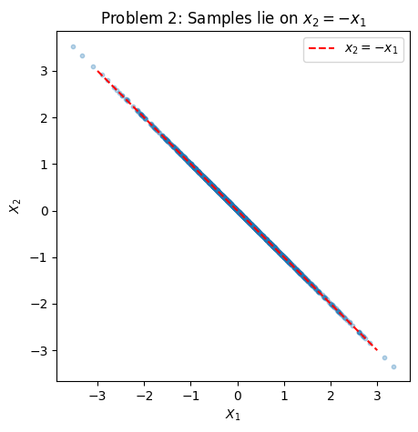

```
All samples satisfy X2 = -X1: True
```

```python
# X = L @ Z where L = [[1,0],[-1,0]], Z ~ N(0,I)
# So X1 = Z1, X2 = -Z1 : samples lie exactly on x2 = -x1
Z1 = np.random.normal(0, 1, 1000)
X2_p2 = np.column_stack([Z1, -Z1])

plt.figure(figsize=(5, 5))
plt.scatter(X2_p2[:, 0], X2_p2[:, 1], alpha=0.3, s=10)
x_line = np.linspace(-3, 3, 100)
plt.plot(x_line, -x_line, 'r--', label='$x_2 = -x_1$')
plt.xlabel("$X_1$")
plt.ylabel("$X_2$")
plt.title("Problem 2: Samples lie on $x_2 = -x_1$")
plt.legend()
plt.axis('equal')
plt.show()
print("All samples satisfy X2 = -X1:", np.allclose(X2_p2[:,0] + X2_p2[:,1], 0))
```

# Problem 3

In this problem, we will simulate correlated exponential random variables with the method of copulas.

## Part a

Let $Z_1$ and $Z_2$ be standard normal random variables with correlation $\rho = 0.5$. Simulate $10,000$ samples of the random vector $\mathbf{Z} = (Z_1, Z_2)$. Make a scatter plot and histograms of your samples (i.e., plot $Z_1$ vs $Z_2$ and then plot the histogram of $Z_1$ and the histogram of $Z_2$) and calculate the sample correlation to confirm that they have the correct distribution.

## Part b

For each of your samples from part (a), calculate the vector

$$\mathbf{U} = \begin{pmatrix} U_1 \\ U_2 \end{pmatrix} = \begin{pmatrix} F_Z(Z_1) \\ F_Z(Z_2) \end{pmatrix}$$

where $F_Z$ is the cdf of the standard normal distribution. (You can calculate $F_Z$ in python using `scipy.special.ndtr()`.) Make a scatter plot and histograms of your samples (i.e., plot $U_1$ vs $U_2$ and then plot the histogram of $U_1$ and the histogram of $U_2$) and calculate the sample correlation. Do $U_1$ and $U_2$ appear to be uniformly distributed? Do they appear to be correlated? Does the correlation appear to be the same as $\textrm{Corr}[Z_1, Z_2]$?

## Part c

For each of your samples from part (b), calculate the vector

$$\mathbf{X} = \begin{pmatrix} X_1 \\ X_2 \end{pmatrix} = \begin{pmatrix} F^{-1}(U_1) \\ F^{-1}(U_2) \end{pmatrix}$$

where $F$ is the cdf of an exponential random variable with parameter $\lambda = 1$. Make a scatter plot and histograms of your samples (i.e., plot $X_1$ vs $X_2$ and then plot this histogram of $X_1$ and the histogram of $X_2$) and calculate the sample correlation. Do $X_1$ and $X_2$ appear to be exponentially distributed? Do they appear to be correlated? Does the correlation appear to be the same as $\textrm{Corr}[Z_1, Z_2]$?

## Part d

Repeat the sampling process from parts (a)-(b) for $\rho = -1$, $\rho = -0.9$, $\dotsc$, $\rho = 0.9$, \rho = 1$. That is, for each of the 21 values of $\rho$, simulate $10,000$ samples of $\mathbf{Z}$ with the appropriate correlation, then calculate

$$\mathbf{X} = \begin{pmatrix} F^{-1}(F_Z(Z_1)) \\ F^{-1}(F_Z(Z_2)) \end{pmatrix}$$

Plot $\textrm{Corr}[X_1, X_2]$ vs $\rho$.

**Solution**

**Part a** : Generate $\mathbf{Z} = (Z_1, Z_2)$ with $\mathrm{Corr}[Z_1, Z_2] = 0.5$ using Cholesky:

$$\Sigma_Z = \begin{pmatrix}1 & 0.5 \\ 0.5 & 1\end{pmatrix} = LL^T, \qquad \mathbf{Z} = L\mathbf{W}, \quad \mathbf{W} \sim N(\mathbf{0}, I)$$

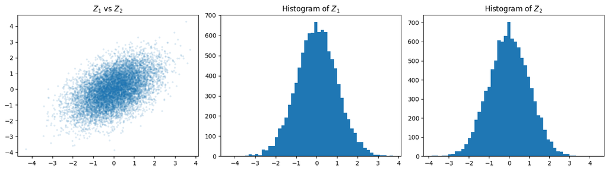

```
Sample correlation: 0.4910  (exact: 0.5)
```

```python
# Part a: Z1, Z2 ~ N(0,1) with correlation rho=0.5 via Cholesky
rho = 0.5
Sigma_z = np.array([[1.0, rho], [rho, 1.0]])
L_z = np.linalg.cholesky(Sigma_z)
Z = np.random.normal(0, 1, (10_000, 2)) @ L_z.T

fig, axes = plt.subplots(1, 3, figsize=(14, 4))
axes[0].scatter(Z[:, 0], Z[:, 1], alpha=0.1, s=5)
axes[0].set_title("$Z_1$ vs $Z_2$")
axes[1].hist(Z[:, 0], bins=50)
axes[1].set_title("Histogram of $Z_1$")
axes[2].hist(Z[:, 1], bins=50)
axes[2].set_title("Histogram of $Z_2$")
plt.tight_layout(); plt.show()
print(f"Sample correlation: {np.corrcoef(Z.T)[0,1]:.4f}  (exact: {rho})")
```

**Part b** : Apply the probability integral transform $U_i = F_Z(Z_i) = \Phi(Z_i)$.

By the PIT, if $Z_i$ is continuous with CDF $\Phi$, then $U_i = \Phi(Z_i) \sim \mathrm{Uniform}(0,1)$. The $U_i$ retain the dependence structure of $Z$ but have uniform marginals : this is the Gaussian copula.

Note: $\mathrm{Corr}[U_1, U_2] \neq \mathrm{Corr}[Z_1, Z_2]$ in general, since the CDF transform is nonlinear.

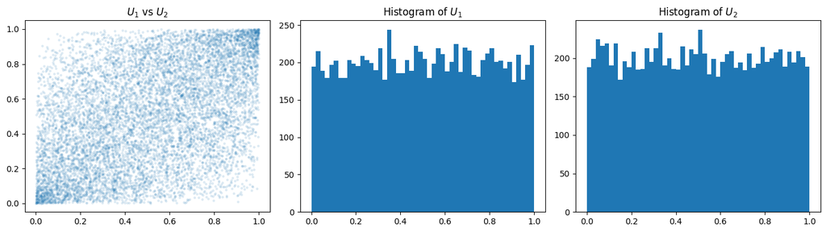

```
Sample correlation of U: 0.4673
```

```python
# Part b: U = (Phi(Z1), Phi(Z2)) -- uniform marginals
U = ndtr(Z)

fig, axes = plt.subplots(1, 3, figsize=(14, 4))
axes[0].scatter(U[:, 0], U[:, 1], alpha=0.1, s=5)
axes[0].set_title("$U_1$ vs $U_2$")
axes[1].hist(U[:, 0], bins=50)
axes[1].set_title("Histogram of $U_1$")
axes[2].hist(U[:, 1], bins=50)
axes[2].set_title("Histogram of $U_2$")
plt.tight_layout(); plt.show()
corr_u = np.corrcoef(U.T)[0,1]
print(f"Sample correlation of U: {corr_u:.4f}")
```

**Part c** : Apply the inverse CDF of $\mathrm{Exp}(1)$ to each $U_i$.

For $\mathrm{Exp}(1)$: $F(x) = 1 - e^{-x}$, so $F^{-1}(u) = -\ln(1-u)$.

$$X_i = F^{-1}(U_i) = -\ln(1-U_i) \sim \mathrm{Exp}(1)$$

The marginals of $X$ are exponential, but $X_1$ and $X_2$ remain correlated because $U_1, U_2$ were correlated. However, $\mathrm{Corr}[X_1, X_2] \neq \rho$ since the nonlinear transforms change linear correlation.

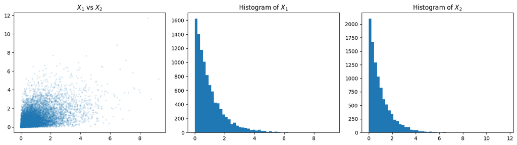

```
Sample correlation of X: 0.4604
```

```python
# Part c: X = F_Exp^{-1}(U) where F_Exp(x) = 1 - e^{-x}, so F^{-1}(u) = -ln(1-u)
X_cop = -np.log(1 - U)

fig, axes = plt.subplots(1, 3, figsize=(14, 4))
axes[0].scatter(X_cop[:, 0], X_cop[:, 1], alpha=0.1, s=5)
axes[0].set_title("$X_1$ vs $X_2$")
axes[1].hist(X_cop[:, 0], bins=50)
axes[1].set_title("Histogram of $X_1$")
axes[2].hist(X_cop[:, 1], bins=50)
axes[2].set_title("Histogram of $X_2$")
plt.tight_layout(); plt.show()
corr_x = np.corrcoef(X_cop.T)[0,1]
print(f"Sample correlation of X: {corr_x:.4f}")
```

**Part d** : Sweep $\rho \in \{-1, -0.9, \ldots, 0.9, 1\}$ and compute $\mathrm{Corr}[X_1, X_2]$ for each.

For each $\rho$, generate $\mathbf{Z}$ via Cholesky, transform to $\mathbf{U} = \Phi(\mathbf{Z})$, then to $\mathbf{X} = F^{-1}(\mathbf{U})$. The plot shows that the copula-induced correlation in $X$ is a monotone but nonlinear function of $\rho$.

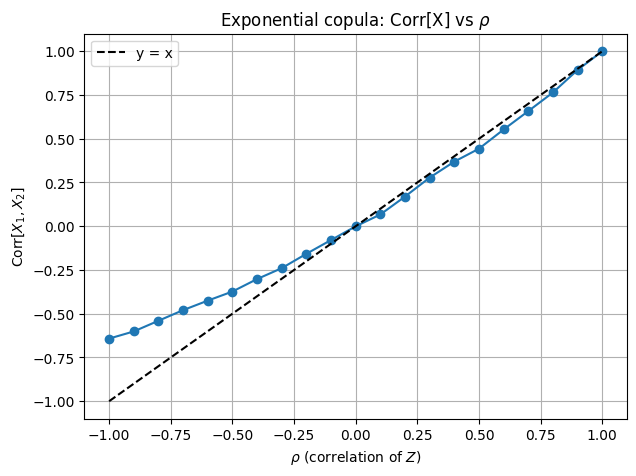

```python
# Part d: sweep rho from -1 to 1 using Cholesky
rhos = np.linspace(-1, 1, 21)
corr_x_vals = []
for r in rhos:
    Z1 = np.random.normal(0, 1, 10_000)
    if abs(r) == 1:
        # Degenerate case: Z2 = sign(r)*Z1 exactly
        Z_sweep = np.column_stack([Z1, np.sign(r) * Z1])
    else:
        Sigma_sweep = np.array([[1.0, r], [r, 1.0]])
        L_sweep = np.linalg.cholesky(Sigma_sweep)
        Z2 = r * Z1 + np.sqrt(1 - r**2) * np.random.normal(0, 1, 10_000)
        Z_sweep = np.column_stack([Z1, Z2])
    U_sweep = ndtr(Z_sweep)
    X_sweep = -np.log(1 - U_sweep)
    corr_x_vals.append(np.corrcoef(X_sweep.T)[0, 1])

plt.figure(figsize=(7, 5))
plt.plot(rhos, corr_x_vals, 'o-')
plt.plot([-1, 1], [-1, 1], 'k--', label='y = x')
plt.xlabel(r"$\rho$ (correlation of $Z$)")
plt.ylabel(r"$\mathrm{Corr}[X_1, X_2]$")
plt.title("Exponential copula: Corr[X] vs $\\rho$")
plt.legend(); plt.grid(True); plt.show()
```

# Problem 4

Consider a three-state, discrete time Markov chain with states $1$, $2$ and $3$ and transition matrix

$$P = \begin{pmatrix} 0.9 & 0.07 & 0.03 \\ 0.12 & 0.8 & 0.08 \\ 0.2 & 0.3 & 0.5 \end{pmatrix}$$

## Part a

Generate one trajectory from $t = 0$ to $t = 100,000$ of this Markov chain and plot the first 500 time steps of the trajectory. (Generate the initial state from a uniform distribution.)

## Part b

Use the full trajectory you calculated in part (a) to estimate the expected proportion of time spent in each state.

## Part c

Calculate the dominant eigenvalue of $P$ and its corresponding left eigenvector. How does this eigenvector relate to the expected times you found in part (2)?

**Solution**

**Parts a & b** : Simulate the chain using the inverse transform method on each row of $P$.

At each step, draw $U \sim \mathrm{Uniform}(0,1)$ and find the smallest $k$ such that $\sum_{j=1}^k P_{\text{state},j} \geq U$. This is equivalent to `np.random.choice` but uses only uniform primitives.

The initial state is drawn uniformly from $\{1,2,3\}$ via $\lfloor 3U \rfloor$.

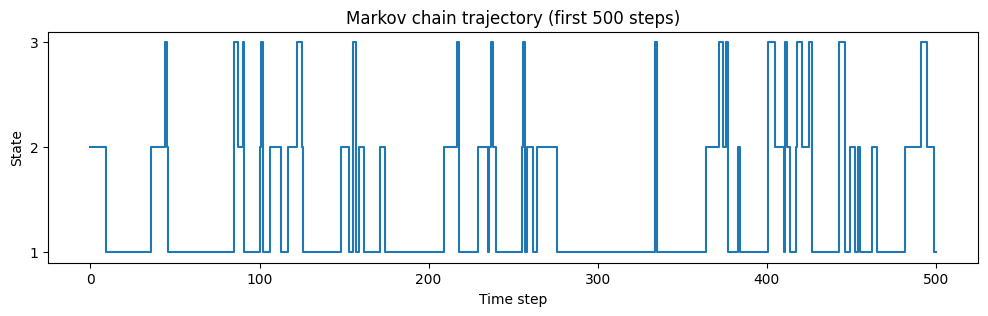

```
Part b : Empirical proportion of time in each state:
  State 1: 0.5765
  State 2: 0.3348
  State 3: 0.0887
```

```python
P = np.array([[0.9,  0.07, 0.03],
              [0.12, 0.8,  0.08],
              [0.2,  0.3,  0.5 ]])

def next_state(current, P, u):
    """Inverse transform on discrete distribution row P[current]."""
    cdf = 0.0
    for k in range(P.shape[1]):
        cdf += P[current, k]
        if u <= cdf:
            return k
    return P.shape[1] - 1

n_steps = 100_000
states = np.zeros(n_steps + 1, dtype=int)

# Initial state uniform on {0,1,2} via inverse transform
u0 = np.random.uniform()
states[0] = int(u0 * 3)

# Generate trajectory using uniform draws + inverse transform
U = np.random.uniform(size=n_steps)
for t in range(n_steps):
    states[t + 1] = next_state(states[t], P, U[t])

# Part a: plot first 500 steps
plt.figure(figsize=(12, 3))
plt.step(range(501), states[:501] + 1)
plt.xlabel("Time step"); plt.ylabel("State")
plt.yticks([1, 2, 3])
plt.title("Markov chain trajectory (first 500 steps)")
plt.show()

# Part b: proportion of time in each state
print("Part b : Empirical proportion of time in each state:")
for s in range(3):
    print(f"  State {s+1}: {np.mean(states == s):.4f}")
```

**Part c** : The stationary distribution $\boldsymbol{\pi}$ satisfies $\boldsymbol{\pi} P = \boldsymbol{\pi}$, i.e., it is the left eigenvector of $P$ corresponding to eigenvalue 1.

Equivalently, $P^T \boldsymbol{\pi} = \boldsymbol{\pi}$ (right eigenvector of $P^T$). For any irreducible, aperiodic Markov chain, the dominant eigenvalue is 1 and the corresponding normalized eigenvector gives the long-run fraction of time spent in each state.

```python
# Part c: dominant eigenvalue and left eigenvector of P
# Left eigenvector: pi P = pi  <=>  P^T pi = pi
eigenvalues, eigenvectors = np.linalg.eig(P.T)
idx = np.argmax(np.real(eigenvalues))
dominant_eigenvalue = np.real(eigenvalues[idx])
pi = np.real(eigenvectors[:, idx])
pi = pi / pi.sum()

print(f"Dominant eigenvalue: {dominant_eigenvalue:.6f}")
print(f"Stationary distribution: {pi.round(4)}")
```

```
Dominant eigenvalue: 1.000000
Stationary distribution: [0.5775 0.3343 0.0881]
```

# Problem 5

Suppose $S\sim GBM(0.1, 0.3)$. In this problem, you will simulate $S_{t_k}$ at the times $t_k = 0.01k$ for $0 \leq k \leq 1000$. Use the initial condition $S_0 = 1$.

## Part a

Simulate $S$ once and plot the trajectory.

## Part b

Simulate $S$ at least $10,000$ times and plot the mean trajectory.

## Part c

Estimate the probability that the maximum of $S_{t_k}$ is no greater than 6.

## Part d

Estimate the probability that $S_{t_k}$ ever leaves the interval $[0.25, 10]$.

**Solution**

For $S \sim \mathrm{GBM}(\mu, \sigma)$, the exact discretization at times $t_k = k\,\Delta t$ is:

$$S_{t_{k+1}} = S_{t_k} \exp\!\left(\left(\mu - \tfrac{1}{2}\sigma^2\right)\Delta t + \sigma\sqrt{\Delta t}\,Z_k\right), \quad Z_k \stackrel{\text{iid}}{\sim} N(0,1)$$

This is exact (not an approximation) because GBM has log-normal increments. The theoretical mean is $\mathbb{E}[S_t] = S_0 e^{\mu t}$.

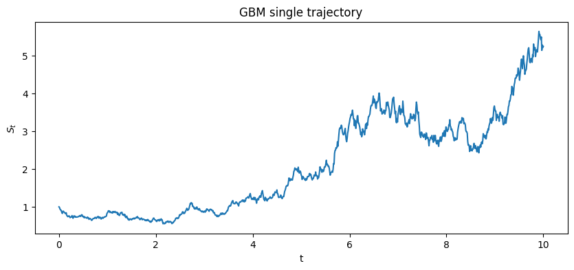

```python
mu_gbm, sigma_gbm, S0 = 0.1, 0.3, 1.0
dt, n_steps = 0.01, 1000
t = np.arange(n_steps + 1) * dt

def simulate_gbm(mu, sigma, S0, dt, n_steps):
    Z = np.random.normal(0, 1, n_steps)
    log_ret = (mu - 0.5 * sigma**2) * dt + sigma * np.sqrt(dt) * Z
    return S0 * np.exp(np.concatenate([[0], np.cumsum(log_ret)]))

# Part a: single trajectory
S_single = simulate_gbm(mu_gbm, sigma_gbm, S0, dt, n_steps)
plt.figure(figsize=(10, 4))
plt.plot(t, S_single)
plt.xlabel("t"); plt.ylabel("$S_t$")
plt.title("GBM single trajectory")
plt.show()
```

**Part b** : Simulate $10{,}000$ trajectories and plot the sample mean against the theoretical mean $\mathbb{E}[S_t] = e^{\mu t}$.

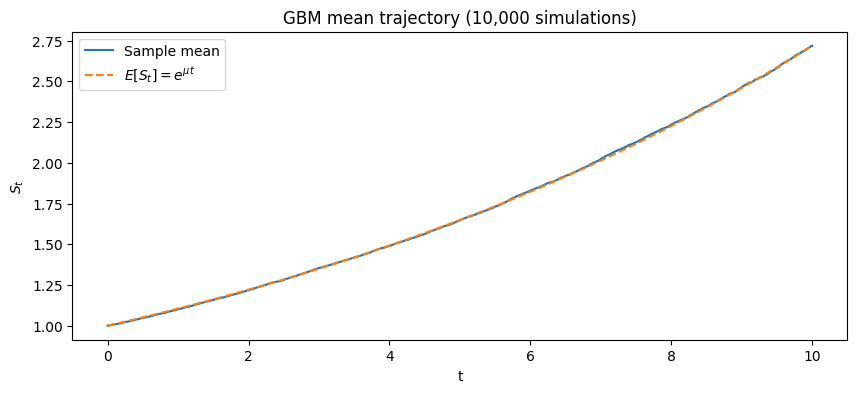

```python
# Part b: 10,000 trajectories, mean trajectory
n_sim = 10_000
S_all = np.array([simulate_gbm(mu_gbm, sigma_gbm, S0, dt, n_steps) for _ in range(n_sim)])

plt.figure(figsize=(10, 4))
plt.plot(t, S_all.mean(axis=0), label="Sample mean")
plt.plot(t, S0 * np.exp(mu_gbm * t), '--', label=r"$E[S_t] = e^{\mu t}$")
plt.xlabel("t"); plt.ylabel("$S_t$")
plt.title("GBM mean trajectory (10,000 simulations)")
plt.legend(); plt.show()
```

**Part c** : Estimate $P(\max_{k} S_{t_k} \leq 6)$ as the fraction of trajectories whose maximum never exceeds 6.

**Part d** : Estimate $P(S_{t_k} \text{ ever leaves } [0.25, 10])$ as the fraction of trajectories that at some point fall below 0.25 or exceed 10.

```python
# Part c: P(max(S_tk) <= 6)
max_S = S_all.max(axis=1)
prob_c = np.mean(max_S <= 6)
print(f"Part c : P(max S_tk <= 6) = {prob_c:.4f}")

# Part d: P(S ever leaves [0.25, 10])
leaves = np.any((S_all < 0.25) | (S_all > 10), axis=1)
prob_d = np.mean(leaves)
print(f"Part d : P(S leaves [0.25, 10]) = {prob_d:.4f}")
```

```
Part c : P(max S_tk <= 6) = 0.8522
Part d : P(S leaves [0.25, 10]) = 0.1020
```